# Racial Exploration

# 1 Introduction

This document uses an interrupted time series ARIMA analysis to evaluate changes in mortality among Texas female residents aged 15-44 to see whether racial differences exist. Data were previously cleaned in the document `/Scripts/Cleaning.Rmd`

Data are from the CDC Multiple Cause of Death Database, including monthly Texas resident death counts from 2018-Dec 2023. Racial/ethnic groups are grouped as follows:

1. Hispanic (any race)
2. Non-Hispanic White
3. Non-Hispanic Black
4. Non-Hispanic Asian
5. Non-Hispanic Native Hawaiian or other Pacific Islander
6. Non-Hispanic American Indian or Alaska Native

# 2 Methods

R code is adapted from this [RPubs article on tidy structure for ITS ARIMAs](https://rpubs.com/jcorbin/tidy_itt_arima)

The ARIMA model incorporates:

- **Autoregressive terms (AR)** to capture dependence on previous observations
- **Integrated differencing (I)** to remove non-stationary trends
- **Moving average terms (MA)** to account for serial correlation in residual errors

The intervention is modeled using:

- **Step variable**: immediate level change after the intervention
- **Ramp variable**: gradual slope change after the intervention

Counterfactual forecasts are generated using the **pre-intervention ARIMA structure**, representing expected mortality trajectories if the policy had not occurred.

## 2.1 Analysis Structure

1. Exploration

We will start by exploring the distribution of deaths among each of these racial groups, identifying how much data are missing. 2. ARIMA fits

We will then explore what the ARIMAs indicate about death trends using June 2021 as an interruption point.

# 3 Exploration

To start, let’s see what the top 4 highest death counts are for each group.

```
## # A tibble: 16 × 3
## # Groups:   race_eth [4]
##    race_eth                  Deaths month_year
##    <chr>                      <int> <chr>
##  1 Asian                         23 2020-02-01
##  2 Asian                         21 2022-09-01
##  3 Asian                         20 2021-09-01
##  4 Asian                         18 2023-05-01
##  5 Black or African American    201 2021-09-01
##  6 Black or African American    176 2021-08-01
##  7 Black or African American    136 2022-01-01
##  8 Black or African American    131 2021-10-01
##  9 Hispanic                     340 2021-08-01
## 10 Hispanic                     336 2021-09-01
## 11 Hispanic                     245 2021-10-01
## 12 Hispanic                     241 2020-07-01
## 13 White                        297 2021-08-01
## 14 White                        297 2021-09-01
## 15 White                        274 2021-10-01
## 16 White                        252 2022-01-01
```

Let’s see it graphically:

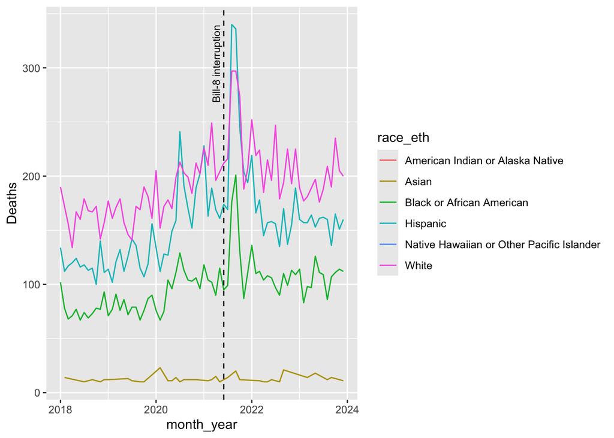

```r
racial$month_year <- as.Date(racial$month_year)
ggplot(racial, aes(x = month_year, y = Deaths, color = race_eth)) +
  geom_line()+
  geom_vline(xintercept = as.Date("2021-06-01"), linetype = "dashed", color = "black") +
 annotate("text", x = as.Date("2021-06-01"), y = max(racial$Deaths, na.rm = TRUE),
           label = "Bill-8 interruption", angle = 90, vjust = -0.5, hjust = 1, size = 3)
```

We don’t seem to have many dataponits for Hawaiian, which makes sense. But overall it does appear ike we have good data coverage!

Next, let’s assess how many months of death data are missing for each group.

```r
racial %>%
  group_by(race_eth) %>%
  summarize(
    missing_count = sum(is.na(Deaths)),
    .groups = "drop"
  )
```

```
## # A tibble: 6 × 2
##   race_eth                                  missing_count
##   <chr>                                             <int>
## 1 American Indian or Alaska Native                     23
## 2 Asian                                                 0
## 3 Black or African American                             0
## 4 Hispanic                                              0
## 5 Native Hawaiian or Other Pacific Islander            29
## 6 White                                                 0
```

As expected, missing a lot for Native Hawaiian. Also missing quite a lot for American Indian/Alaska Native. We generally need at least 12 observations before and after the interruption point, so we will have to exclude American Indian and Native Hawaiian from this study.

```r
racial <- racial %>%
  filter(!race_eth %in% c("Native Hawaiian or Other Pacific Islander", "American Indian or Alaska Native"))
```

Now that we’ve explored a little, it’s time to fit some ARIMAS.

# 4 ARIMA Analysis

## 4.1 Hispanic

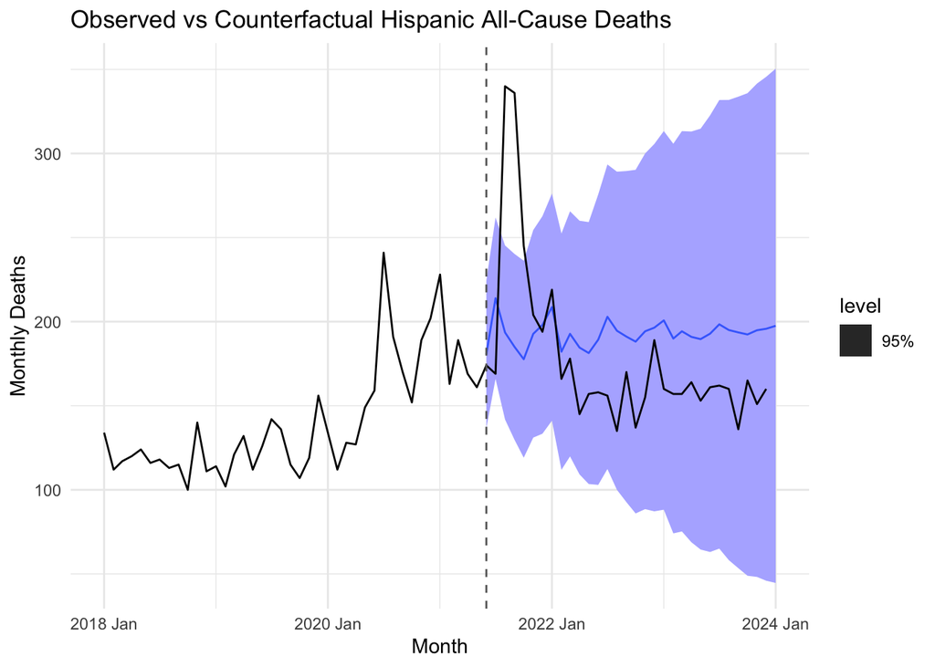

```r
hispanic <- racial %>%
  filter(race_eth == "Hispanic") %>%
  arrange(month_year) %>%
  mutate(time = row_number())

monthly.ts <- prepare_ts_df(hispanic)
monthly.ts <- create_intervention(monthly.ts, "2021-06-01")

m_arima <- fit_arima(monthly.ts)

fc_m <- counterfactual_forecast(monthly.ts, "2021-06-01", 32)

plot_counterfactual(
  fc_m,
  monthly.ts,
  "2021-06-01",
  "Observed vs Counterfactual Hispanic All-Cause Deaths"
)
```

## 4.2 Non-Hispanic White

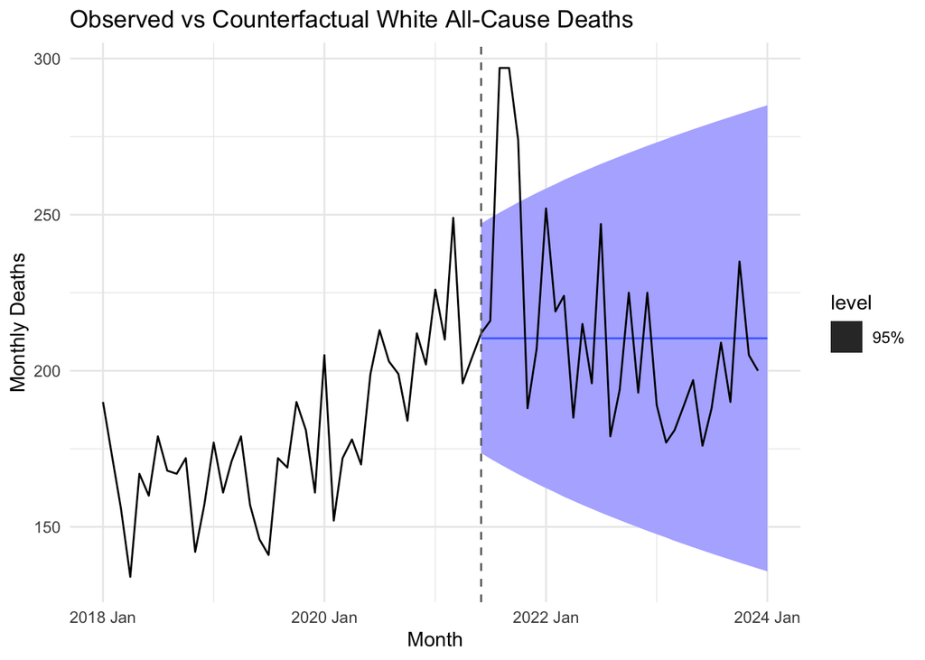

```r
white  <- racial %>%
  filter(race_eth == "White") %>%
  arrange(month_year) %>%
  mutate(time = row_number())

monthly.ts <- prepare_ts_df(white)
monthly.ts <- create_intervention(monthly.ts, "2021-06-01")

m_arima <- fit_arima(monthly.ts)

fc_m <- counterfactual_forecast(monthly.ts, "2021-06-01", 32)

plot_counterfactual(
  fc_m,
  monthly.ts,
  "2021-06-01",
  "Observed vs Counterfactual White All-Cause Deaths"
)
```

## 4.3 Non-Hispanic Black

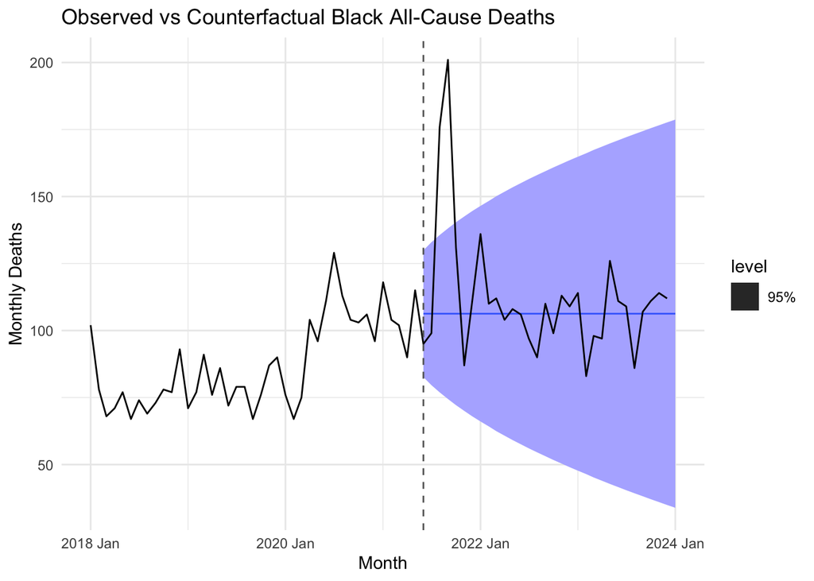

```r
black <- racial %>%
  filter(race_eth == "Black or African American") %>%
  arrange(month_year) %>%
  mutate(time = row_number())

monthly.ts <- prepare_ts_df(black)
monthly.ts <- create_intervention(monthly.ts, "2021-06-01")

m_arima <- fit_arima(monthly.ts)

fc_m <- counterfactual_forecast(monthly.ts, "2021-06-01", 32)

plot_counterfactual(
  fc_m,
  monthly.ts,
  "2021-06-01",
  "Observed vs Counterfactual Black All-Cause Deaths"
)
```

## 4.4 Non-Hispanic Asian

I have the code for NH Asian, but we don’t actually have data on the date itself of June 2021, so I can’t run the model.

In the future we may want to revisit, possibly interpolating (though I believe this is against CDC Wonder rules, so perhaps we just won’t be able to examine Asian Deaths in particular.)

```r
asian <- racial %>%
  filter(race_eth == "Asian") %>%
  arrange(month_year) %>%
  mutate(time = row_number())

monthly.ts <- prepare_ts_df(asian)
monthly.ts <- create_intervention(monthly.ts, "2021-06-01")

m_arima <- fit_arima(monthly.ts)

fc_m <- counterfactual_forecast(monthly.ts, "2021-06-01", 32)

plot_counterfactual(
  fc_m,
  monthly.ts,
  "2021-06-01",
  "Observed vs Counterfactual Asian All-Cause Deaths"
)
```